# Human Activity Recognition Prediction Assignment

## by Shannon Poskus

### February 5, 2021

### Introduction

This analysis is looking at Human Activity Recognition data from accelerometers on the belt, forearm, arm, and dumbell of 6 participants while they did barbell lifts. The participents did the barbell lift in 5 different ways, some correct and some incorrect ways of doing the exercise. The goal of this report is to show how to predict which method a person is using based on their accelerometer data.

First retrieve the data and format it to allow analysis. Multiple columns of the data contain either “NA” values or were left empty, be sure to remove those columns as they can’t be used as predictors with missing or non-existent data. Also remove the columns that are not from accelerometer data in order to prevent them from forming false associations.

```r
# load data
file_training <- file("pml-training.csv")
file_testing <- file("pml-testing.csv")

training_data <- read.csv(file_training, header = TRUE, na.strings = c("", "NA"))
testing_data <- read.csv(file_testing, header = TRUE, na.strings = c("", "NA"))

# clean data
training <- training_data %>% select_if(~ !any(is.na(.)))
testing <- testing_data %>% select_if(~ !any(is.na(.)))

# remove front columns
training <- training[, -c(1:7)]
testing <- testing[, -c(1:7)]
```

### Building the Model

Next split the training set into two data sets, the base training set and a validation set, and use the base training set to create the first model using Recusive Partitioning Trees.

```r
# set seed for reproducibility
set.seed(37429)

# split the data 75% to 25%
dataSplit <- createDataPartition(training$classe, p=0.75, list = FALSE)
baseTraining <- training[dataSplit,]
validTraining <- training[-dataSplit,]

# create the first model using rpart
model1 <- rpart(classe ~ ., data = baseTraining, method = "class")

# look at the cost complexity parameter for the first model
printcp(model1)
```

```
##
## Classification tree:
## rpart(formula = classe ~ ., data = baseTraining, method = "class")
##
## Variables actually used in tree construction:
##  [1] accel_dumbbell_y  accel_dumbbell_z  accel_forearm_x   magnet_belt_z
##  [5] magnet_dumbbell_y magnet_dumbbell_z pitch_belt        pitch_forearm
##  [9] roll_belt         roll_dumbbell     roll_forearm      yaw_arm
## [13] yaw_belt
##
## Root node error: 10533/14718 = 0.71565
##
## n= 14718
##
##          CP nsplit rel error  xerror      xstd
## 1  0.116966      0   1.00000 1.00000 0.0051957
## 2  0.041837      1   0.88303 0.88503 0.0055503
## 3  0.040444      7   0.63201 0.66942 0.0057539
## 4  0.023798      8   0.59157 0.60534 0.0057073
## 5  0.020412     11   0.52017 0.53461 0.0055979
## 6  0.019653     12   0.49976 0.51210 0.0055498
## 7  0.013909     13   0.48011 0.48381 0.0054799
## 8  0.013292     17   0.42058 0.44166 0.0053552
## 9  0.013102     18   0.40729 0.43577 0.0053357
## 10 0.011393     19   0.39419 0.42229 0.0052892
## 11 0.010728     20   0.38280 0.40539 0.0052270
## 12 0.010000     21   0.37207 0.38697 0.0051541
```

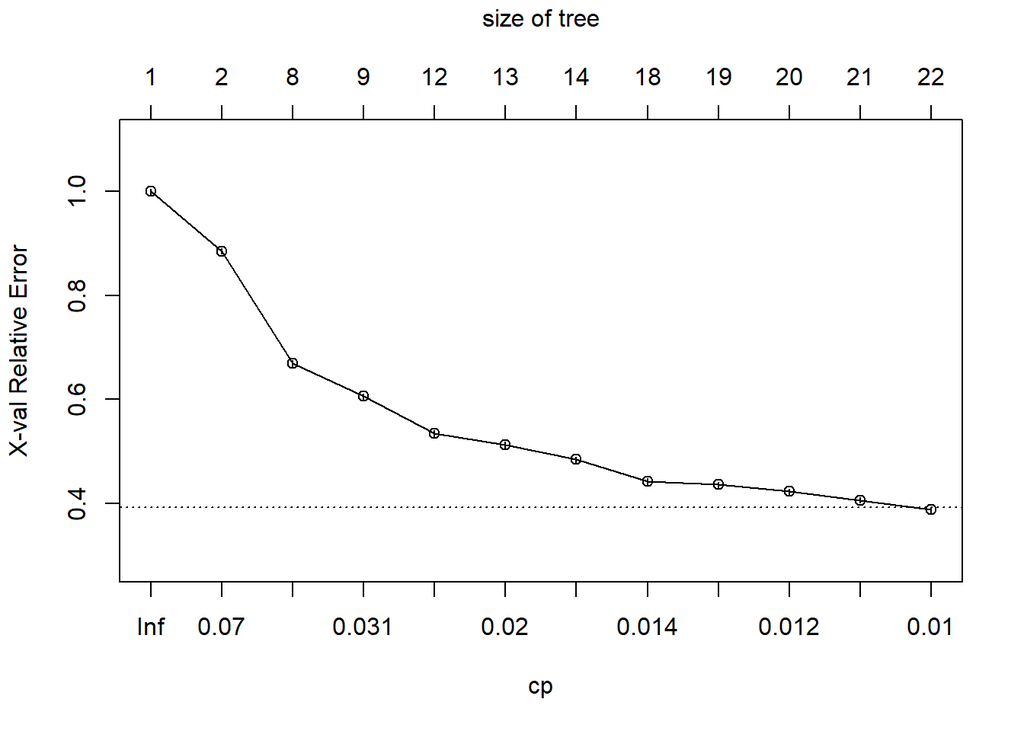

```r
# plot the relative error for the first model
plotcp(model1)
```

```r
# use the predict function on the first model with the validation data set
predict1 <- predict(model1, validTraining, type = "class")

# use the Confusion Matrix to look at the prediction odds for model 1
conMat1 <- confusionMatrix(predict1, validTraining$classe)
conMat1
```

```
## Confusion Matrix and Statistics
##
##           Reference
## Prediction    A    B    C    D    E
##          A 1227  152   17   41   43
##          B   43  579   57   78   76
##          C   33  118  659  215   80
##          D   54   48   33  408   40
##          E   38   52   89   62  662
##
## Overall Statistics
##
##                Accuracy : 0.7208
##                  95% CI : (0.7081, 0.7334)
##     No Information Rate : 0.2845
##     P-Value [Acc > NIR] : < 2.2e-16
##
##                   Kappa : 0.646
##
##  Mcnemar's Test P-Value : < 2.2e-16
##
## Statistics by Class:
##
##                      Class: A Class: B Class: C Class: D Class: E
## Sensitivity            0.8796   0.6101   0.7708   0.5075   0.7347
## Specificity            0.9279   0.9358   0.8898   0.9573   0.9398
## Pos Pred Value         0.8291   0.6951   0.5964   0.6998   0.7331
## Neg Pred Value         0.9509   0.9091   0.9484   0.9084   0.9403
## Prevalence             0.2845   0.1935   0.1743   0.1639   0.1837
## Detection Rate         0.2502   0.1181   0.1344   0.0832   0.1350
## Detection Prevalence   0.3018   0.1699   0.2253   0.1189   0.1841
## Balanced Accuracy      0.9037   0.7729   0.8303   0.7324   0.8373
```

### Cross Validation

Next try using k-fold cross validation with the k set to 8.

```r
# set up the cross fold with k=8
control <- trainControl(method = "cv", number = 8)

# create the second model using the base training data
model2 <- train(classe ~., data = baseTraining, method = "rpart", trControl = control)

# use the predict function on the second model with the validation data set
predict2 <- predict(model2, validTraining)

# use the Confusion Matrix to look at the prediction odds for model 2
conMat2 <- confusionMatrix(validTraining$classe, predict2)
conMat2
```

```
## Confusion Matrix and Statistics
##
##           Reference
## Prediction   A   B   C   D   E
##          A 829   5 259 276  26
##          B 153 168 164 464   0
##          C  22  20 702 111   0
##          D  47   7 233 517   0
##          E  16   3 188 275 419
##
## Overall Statistics
##
##                Accuracy : 0.5373
##                  95% CI : (0.5232, 0.5513)
##     No Information Rate : 0.335
##     P-Value [Acc > NIR] : < 2.2e-16
##
##                   Kappa : 0.4242
##
##  Mcnemar's Test P-Value : < 2.2e-16
##
## Statistics by Class:
##
##                      Class: A Class: B Class: C Class: D Class: E
## Sensitivity            0.7769  0.82759   0.4541   0.3147  0.94157
## Specificity            0.8525  0.83387   0.9544   0.9120  0.89190
## Pos Pred Value         0.5943  0.17703   0.8211   0.6430  0.46504
## Neg Pred Value         0.9322  0.99115   0.7916   0.7254  0.99350
## Prevalence             0.2176  0.04139   0.3153   0.3350  0.09074
## Detection Rate         0.1690  0.03426   0.1431   0.1054  0.08544
## Detection Prevalence   0.2845  0.19352   0.1743   0.1639  0.18373
## Balanced Accuracy      0.8147  0.83073   0.7043   0.6133  0.91674
```

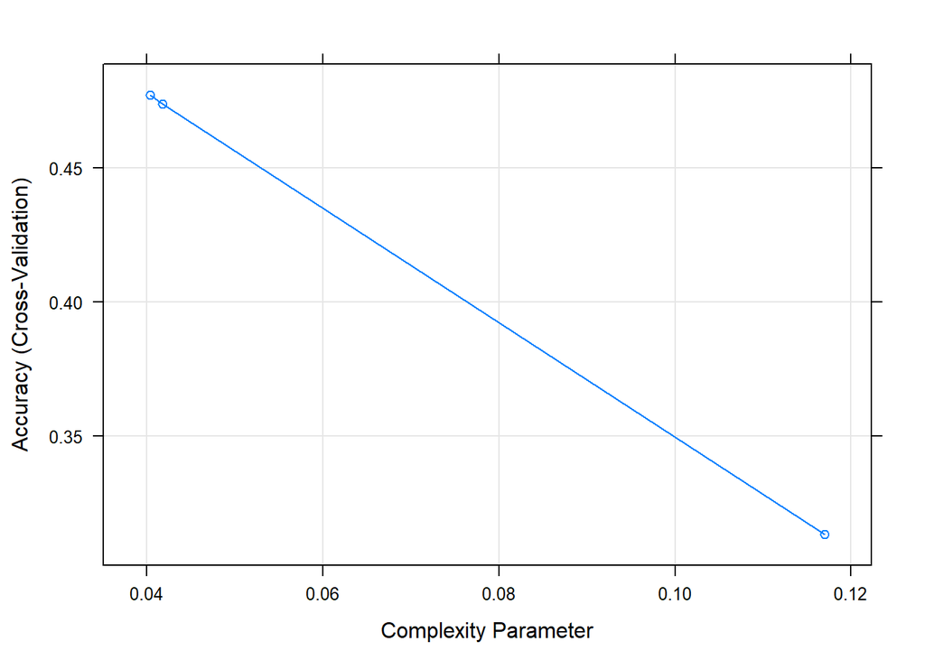

```r
# plot the accuracy of the second model
plot(model2)
```

The second model has even less accuracy than the first, with an accuracy of only 53.73%.

Finally, try creating a model using the Random Forest method on the base training data.

```r
# create the third model using the base training data
model3 <- randomForest(classe ~., data = baseTraining)

# use the predict function on the third model with the validation data set
predict3 <- predict(model3, validTraining, type = "class")

# use the Confusion Matrix to look at the prediction odds for model 3
conMat3 <- confusionMatrix(predict3, validTraining$classe)
conMat3
```

```
## Confusion Matrix and Statistics
##
##           Reference
## Prediction    A    B    C    D    E
##          A 1393    4    0    0    0
##          B    2  941    4    0    0
##          C    0    4  848    5    0
##          D    0    0    3  797    2
##          E    0    0    0    2  899
##
## Overall Statistics
##
##                Accuracy : 0.9947
##                  95% CI : (0.9922, 0.9965)
##     No Information Rate : 0.2845
##     P-Value [Acc > NIR] : < 2.2e-16
##
##                   Kappa : 0.9933
##
##  Mcnemar's Test P-Value : NA
##
## Statistics by Class:
##
##                      Class: A Class: B Class: C Class: D Class: E
## Sensitivity            0.9986   0.9916   0.9918   0.9913   0.9978
## Specificity            0.9989   0.9985   0.9978   0.9988   0.9995
## Pos Pred Value         0.9971   0.9937   0.9895   0.9938   0.9978
## Neg Pred Value         0.9994   0.9980   0.9983   0.9983   0.9995
## Prevalence             0.2845   0.1935   0.1743   0.1639   0.1837
## Detection Rate         0.2841   0.1919   0.1729   0.1625   0.1833
## Detection Prevalence   0.2849   0.1931   0.1748   0.1635   0.1837
## Balanced Accuracy      0.9987   0.9950   0.9948   0.9950   0.9986
```

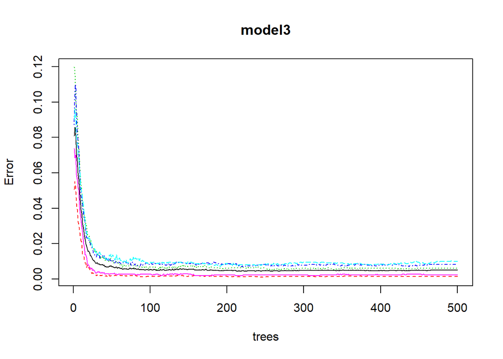

```r
# plot the error for the different trees
plot(model3)
```

The Random Forest method produces a much more accurate model, with an accuracy of 99.47%, so that is the model to use going forward with the actual test data.

### Testing the model

Apply the third model to the test data and check what the resulting predicted barbell lifting methods are.

```r
# use the testing data with the third model
predict_final <- predict(model3, testing, type = "class")
predict_final
```

```
##  1  2  3  4  5  6  7  8  9 10 11 12 13 14 15 16 17 18 19 20
##  B  A  B  A  A  E  D  B  A  A  B  C  B  A  E  E  A  B  B  B
## Levels: A B C D E
```

### Final Notes

The data for this project comes from this source: http://web.archive.org/web/20161224072740/http:/groupware.les.inf.puc-rio.br/har